# Assignment 4

Jeffrey Grove

June 1, 2017

# Question 8.2

```r
peace <- import ("data/PeaceCorpsHW.dta")
```

### (a)

I think there will be a positive relationship between unemployment rate and applications for the peace core. As more people become unemployed, people will look more towards non-traditional means of living which they may not have considered if gainfully employed.

### (b)

```r
pool1 <- lm (appspc ~ unemployrate + yr1 + yr2 + yr3 + yr4 + yr5 + yr6, data = peace)

tidy(pool1)
```

```
##           term  estimate std.error statistic    p.value
## 1  (Intercept) 37.126654 14.748783 2.5172689 0.01234961
## 2 unemployrate  1.106939  1.631738 0.6783805 0.49805516
## 3          yr1 10.388230 10.863460 0.9562542 0.33971631
## 4          yr2  5.049742 10.932244 0.4619127 0.64447983
## 5          yr3 10.053185 10.123210 0.9930827 0.32147261
## 6          yr4 13.001321  8.999862 1.4446134 0.14961362
## 7          yr5  5.384465  9.041287 0.5955419 0.55193183
```

We do not find significance for the unemployment rate at the alpha equals 0.05 level. Therefore we cannot reject the null hypothesis that there is no relationship between unemployment and applications for the peace corps.

### (c)

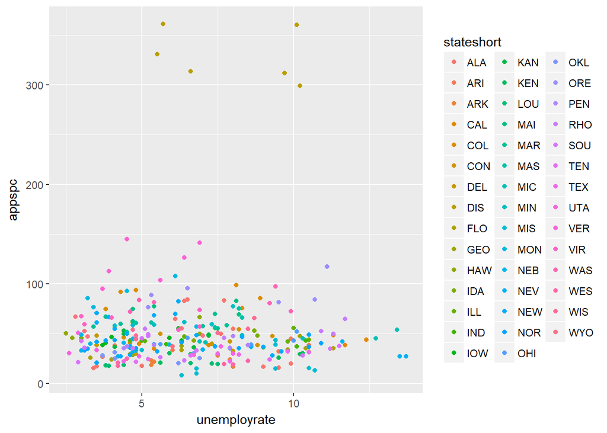

```r
ggplot (data = peace) +

  geom_point (mapping = aes(y = appspc, x = unemployrate, color = stateshort))
```

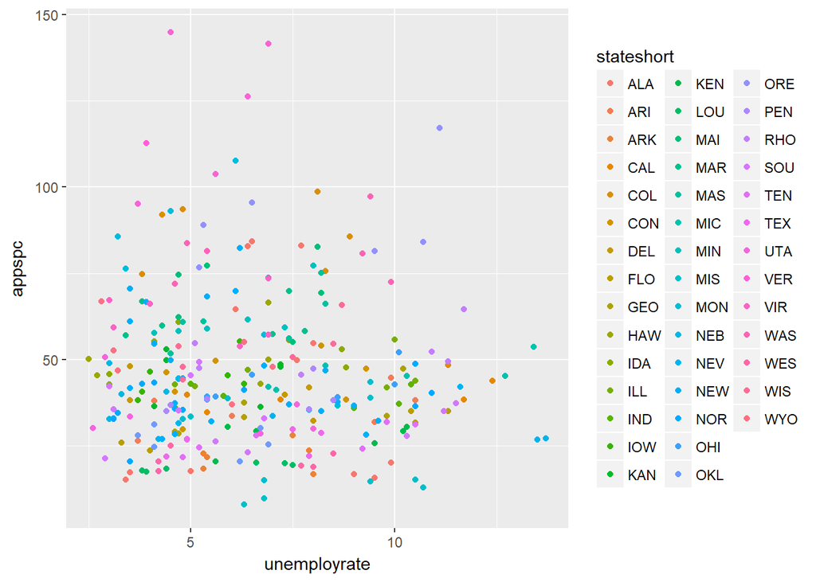

```r
peace1 <- peace %>%

  filter (appspc < 250)

ggplot (data = peace1) +

  geom_point (mapping = aes (x = unemployrate, y = appspc, color = stateshort))
```

There still appears to be no relationship in the new data. We can simply see the data more clearly with the outliers removed.

### (d)

```r
pool2 <- lm (appspc ~ unemployrate + yr1 + yr2 + yr3 + yr4 + yr5 + yr6, data = peace1)

tidy(pool2)
```

```
##           term  estimate std.error  statistic      p.value
## 1  (Intercept) 57.027940 7.0781016  8.0569542 1.994724e-14
## 2 unemployrate -1.963543 0.7860275 -2.4980588 1.303566e-02
## 3          yr1 -2.183451 5.2328858 -0.4172557 6.767970e-01
## 4          yr2 -7.244454 5.2647692 -1.3760251 1.698647e-01
## 5          yr3  1.164934 4.8780991  0.2388090 8.114207e-01
## 6          yr4 13.989168 4.3439206  3.2204014 1.424092e-03
## 7          yr5  6.191496 4.3643673  1.4186468 1.570648e-01
```

### (e)

```r
peaceLSDV <-
  lm(appspc ~ unemployrate + yr1 + yr2 + yr3
     + yr4 + yr5 + yr6 + factor(state), data = peace1)

tidy(peaceLSDV)
```

```
##                           term    estimate std.error  statistic
## 1                  (Intercept)   5.2156276 4.6527237  1.1209838
## 2                 unemployrate   0.8124859 0.4673662  1.7384351
## 3                          yr1   8.1600318 2.1173862  3.8538230
## 4                          yr2   3.2989029 2.1451468  1.5378448
## 5                          yr3   9.0544074 1.7930667  5.0496767
## 6                          yr4  13.0952868 1.2138679 10.7880662
## 7                          yr5   4.4537018 1.2395262  3.5930678
## 8          factor(state)ALASKA  52.5355143 3.4805888 15.0938585
## 9         factor(state)ARIZONA  17.9572417 3.4871720  5.1495142
## 10       factor(state)ARKANSAS   4.9350529 3.4778072  1.4190128
## 11     factor(state)CALIFORNIA  21.8179665 3.6129641  6.0387997
## 12       factor(state)COLORADO  69.9746437 3.4809461 20.1021911
## 13    factor(state)CONNECTICUT  28.9192713 3.4774146  8.3163139
## 14       factor(state)DELAWARE  21.9694339 3.5015232  6.2742505
```

[output cut: 99 more lines]

We still do not find a significant effect of unemployment rate on the applications per capita and thus cannot reject the null hypothesis. However, these results are preferable as they take into account state level fixed effects which the prior model excludes.

### (f) Two way fixed effects

```r
twopeace <- plm(appspc ~ unemployrate,
                data = peace1,
                index = c("state", "year"),
                model = "within",
                effect = "twoways")

tidy(twopeace)
```

```
##           term  estimate std.error statistic   p.value
## 1 unemployrate 0.8124859 0.4673662  1.738435 0.0833956
```

We find the same result with the two way fixed effects model, as a two way LSDV and two way demeaned model should produce the same results!

# Question 8.5

```r
Texas <- import("data/TexasSchoolBoard.dta")
```

### (a)

```r
TxReg1 <- lm(LnAvgSalary ~ OnCycle, data = Texas)

tidy(TxReg1)
```

```
##          term    estimate   std.error    statistic      p.value
## 1 (Intercept) 10.67136324 0.001018375 10478.814561 0.000000e+00
## 2     OnCycle -0.03062071 0.003766094    -8.130628 4.995323e-16
```

We find a highly significant result, however there may be bias in the data, given that a powerful teacher’s union would both be able to set the election schedule and negotiate for better salaries. As such, we should view these results with some skepticism.

### (b)

```r
TxReg2 <- lm(LnAvgSalary ~ CycleSwitch + AfterSwitch + AfterCycleSwitch, data = Texas)

tidy(TxReg2)
```

```
##               term     estimate   std.error   statistic      p.value
## 1      (Intercept) 10.671067840 0.001432820 7447.597740 0.000000e+00
## 2      CycleSwitch -0.023982423 0.003397199   -7.059469 1.827501e-12
## 3      AfterSwitch  0.009303057 0.002188484    4.250914 2.155893e-05
## 4 AfterCycleSwitch -0.008590132 0.005189230   -1.655377 9.789166e-02
```

Our variable of interest is AfterCycleSwitch, for which we do not find statistical significance at the alpha equals 0.05 level, and thus cannot reject the null hypothesis. The districts which switched do experience a decline in salary of 2.3 percent, which we interpret from the coefficient on the cycle switch model. There was a statistically signficant positive change in salary after the switch of just under 1 percent (since this is a logged model).

### (c)

```r
TxFixed <- plm(LnAvgSalary ~ OnCycle,data = Texas, index = c("DistNumber"), model = "within")

tidy(TxFixed)
```

```
##      term     estimate   std.error statistic   p.value
## 1 OnCycle 0.0007903361 0.002077312 0.3804609 0.7036165
```

We find no significant result for our one-way fixed effects model, and thus cannot reject the null hypothesis. This model does not account for time trends which might affect districts, it only accounts for district ID number.

```r
Tx2way <- plm(LnAvgSalary ~ OnCycle + factor(Year), data = Texas, index = c("DistNumber"), model = "within")

tidy(Tx2way)
```

```
##               term     estimate   std.error  statistic       p.value
## 1          OnCycle -0.008516084 0.002024592  -4.206320  2.632738e-05
## 2 factor(Year)2004 -0.020383415 0.001410095 -14.455349  1.352299e-46
## 3 factor(Year)2005 -0.039724498 0.001410095 -28.171505 2.807809e-164
## 4 factor(Year)2006  0.002724874 0.001410499   1.931851  5.342402e-02
## 5 factor(Year)2007 -0.005822403 0.001451775  -4.010542  6.130170e-05
## 6 factor(Year)2008 -0.017732839 0.001451775 -12.214595  6.440868e-34
## 7 factor(Year)2009  0.008437223 0.001451775   5.811662  6.497600e-09
```

We find that OnCycle has a significan effect on average salary. This model accounts for preexisting conditions of switcher districts, as it compares data within districts, rather than grouping all the data together. It further accounts for the effect of post switch years on all districts as we include the fixed effects of all years.

### (e)

We would not be able to estimate the effect of OnCycle for this subset of data, as the switch occurs in 2007. We cannot compare districts to themselves pre- and post-switch, and thus cannot determine the effects of being on-cycle within districts.

# Question 11.3

```r
congress <- import("data/congressRD.dta")
```

### (a)

The district of the congressional member might effect both their ideology and the political party. District level effects include overall level of support for the national party, poeverty, and whiteness.

### (b)

An RD model might fight endogeneity as we can utilize the difference centering around whether a GOP or Democratic congressperson was elected, as districts with close votes should be relatively similar to one another in most respects as the distribution over the discontinuity is quasi-random. This helps control for district level effects.

### (c)

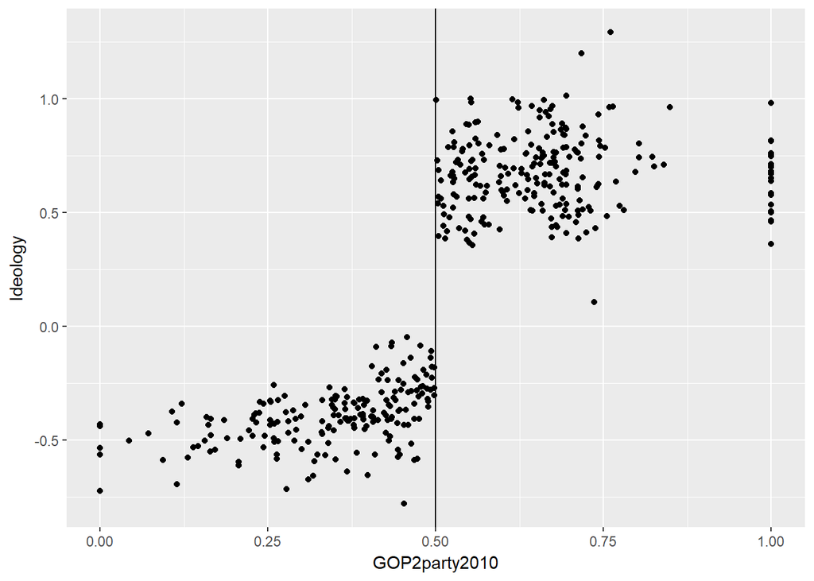

```r
ggplot(data = congress) +
  geom_point(mapping = aes(x = GOP2party2010, y = Ideology), na.rm = TRUE) +
  geom_vline(xintercept = 0.50)
```

The RD will likely indicate that there is an ideological difference between the two parties.

###(d)

$$Ideology_i = \beta_0 + \beta_1*GOPwin2010_i + \beta_2*(GOP2party2010_{1i} - 0.50) + \epsilon_i$$
Ideology is the variable of interest which we are looking to explain with our other variables. $\beta_0$ is the intercept, or the average democratic ideology at the cutoff point. We find the average GOP ideology at the cutoff by adding $\beta_0$ to $\beta_1$. $\beta_2$ is the slope, which is equal for both the democrats and GOP in the basic RDD design. $\epsilon_i$ is, of course, the error term, which in the RDD design, we assume is constant for both groups.

### (e)

```r
congress <- congress %>%
  mutate(GOPwin2010 = factor(GOPwin2010))

congRD1 <- lm(Ideology ~ GOPwin2010 + I(GOP2party2010 - 0.50), data = congress)

tidy(congRD1)
```

```
##                     term   estimate  std.error  statistic       p.value
## 1            (Intercept) -0.3598854 0.01409579 -25.531417  4.108969e-88
## 2            GOPwin20101  0.9951733 0.02381502  41.787627 2.518714e-153
## 3 I(GOP2party2010 - 0.5)  0.2304440 0.05710825   4.035214  6.459328e-05
```

### (f)

```r
congress <- congress %>%
  mutate(adjGOP = GOP2party2010 - 0.5) %>%
  mutate(GOPInt = adjGOP * as.numeric(GOPwin2010))

congVAR <- lm(Ideology ~ GOPwin2010 * adjGOP, data = congress)

tcongVAR <- tidy(congVAR)

tcongVAR
```

```
##                 term   estimate  std.error  statistic       p.value
## 1        (Intercept) -0.3132725 0.01762323 -17.776116  2.421729e-53
## 2        GOPwin20101  0.9815657 0.02356922  41.646077 1.220252e-152
## 3             adjGOP  0.5286074 0.08959227   5.900145  7.389326e-09
## 4 GOPwin20101:adjGOP -0.4893277 0.11477395  -4.263404  2.479081e-05
```

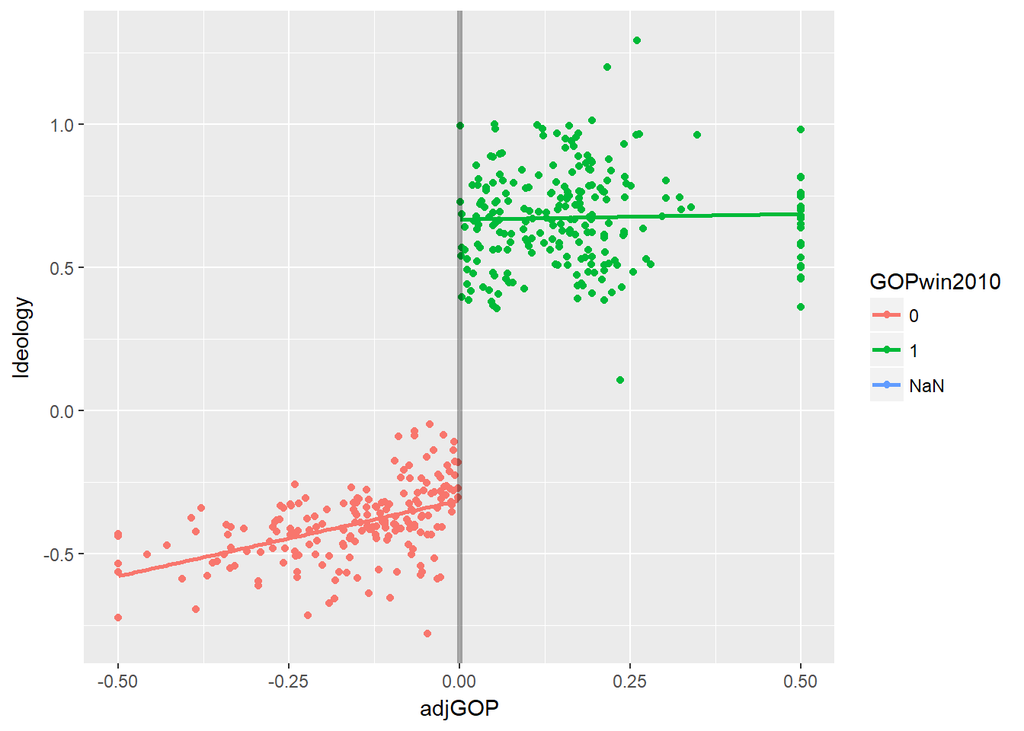

```r
ggplot(data = congress) +
  geom_point(aes(y = Ideology, x = adjGOP, color = GOPwin2010), na.rm = TRUE) +
  geom_smooth(aes(y = Ideology, x = adjGOP, color = GOPwin2010),
              method = "lm", se = FALSE, na.rm = TRUE) +
  geom_vline(aes(xintercept = 0), color = "black", size = 1.25, alpha = 0.33)
```

```r
# fitted values
predfit <- data.frame(GOPwin2010 = as.factor(c(0, 0, 1, 1)), adjGOP = c(-0.5, 0, 0, 0.5))
predict(congVAR, newdata = predfit)
```

```
##          1          2          3          4
## -0.5775762 -0.3132725  0.6682932  0.6879330
```

### (g)

```r
uncongVAR <- lm(Ideology ~ GOPwin2010 * GOP2party2010, data = congress)

untcongVAR <- tidy(uncongVAR)

untcongVAR
```

```
##                        term   estimate  std.error  statistic      p.value
## 1               (Intercept) -0.5775762 0.03259478 -17.719901 4.310325e-53
## 2               GOPwin20101  1.2262296 0.05901227  20.779230 8.035207e-67
## 3             GOP2party2010  0.5286074 0.08959227   5.900145 7.389326e-09
## 4 GOPwin20101:GOP2party2010 -0.4893277 0.11477395  -4.263404 2.479081e-05
```

```r
unpredfit <- data.frame(GOPwin2010 = as.factor(c(0, 0, 1, 1)), GOP2party2010 = c(0, 0.5, 0.5, 1))
predict(uncongVAR, newdata = unpredfit)
```

```
##          1          2          3          4
## -0.5775762 -0.3132725  0.6682932  0.6879330
```

### (h)

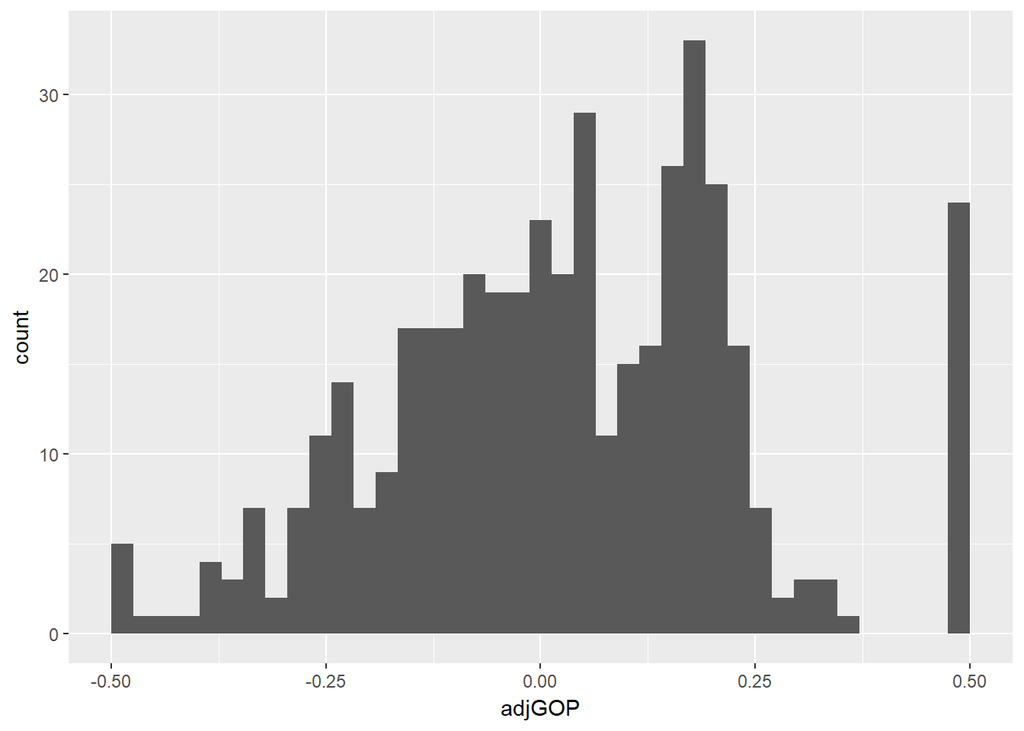

```r
ggplot(data = congress) +
  geom_histogram(aes(x = adjGOP), bins = 40)
```

There does not appear to be clustering in this histogram of the data.

### (i)

```r
chpov <- lm(ChildPoverty ~ GOPwin2010 + adjGOP, data = congress)

tidy(chpov)
```

```
##          term    estimate   std.error  statistic      p.value
## 1 (Intercept)  0.20785971 0.007464587 27.8461107 1.835408e-98
## 2 GOPwin20101 -0.01216113 0.012624222 -0.9633173 3.359272e-01
## 3      adjGOP -0.09769107 0.030315571 -3.2224717 1.367117e-03
```

```r
mdinc <- lm(MedianIncome ~ GOPwin2010 + adjGOP, data = congress)

tidy(chpov)
```

```
##          term    estimate   std.error  statistic      p.value
## 1 (Intercept)  0.20785971 0.007464587 27.8461107 1.835408e-98
## 2 GOPwin20101 -0.01216113 0.012624222 -0.9633173 3.359272e-01
## 3      adjGOP -0.09769107 0.030315571 -3.2224717 1.367117e-03
```

```r
obama <- lm(Obama2008 ~ GOPwin2010 + adjGOP, data = congress)

# There does appear to be a discontinuity here
tidy(obama)
```

```
##          term    estimate   std.error  statistic       p.value
## 1 (Intercept)  0.57667389 0.006244357  92.351208 1.421607e-286
## 2 GOPwin20101 -0.04339804 0.010560551  -4.109448  4.746549e-05
## 3      adjGOP -0.55242270 0.025359910 -21.783307  1.568037e-71
```

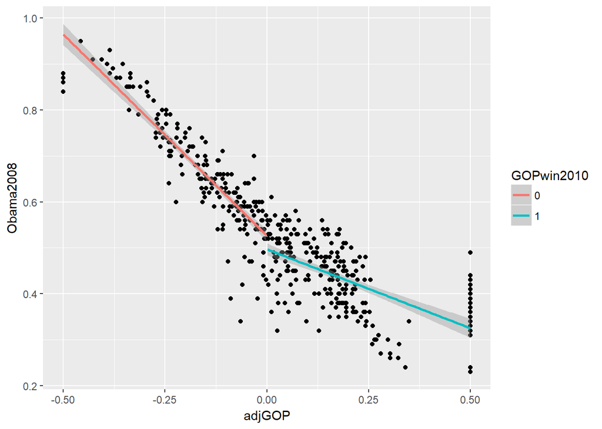

```r
# A graph of the discontinuity
ggplot(data = congress) +
  geom_point(aes(x = adjGOP, y = Obama2008)) +
  geom_smooth(aes(x = adjGOP, y = Obama2008, color = GOPwin2010), method = "lm")
```

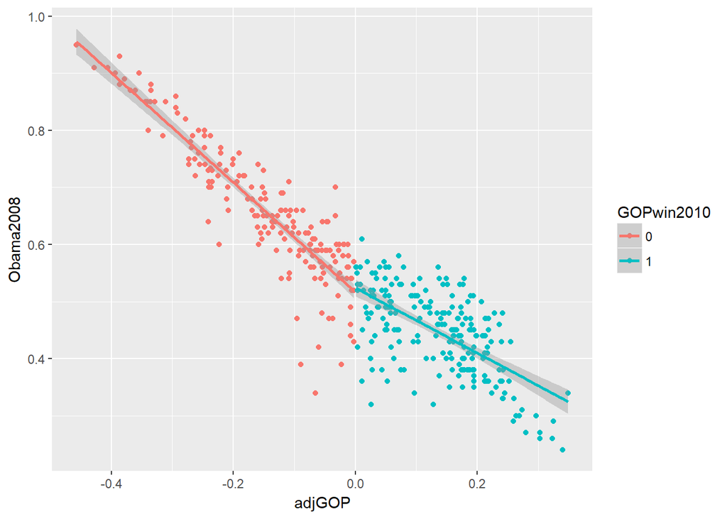

```r
# Removing politicians who ran unopposed we
# observe that there is no longer a discontinuity in the data
ggplot(data = filter(congress, abs(adjGOP) != 0.50)) +
  geom_point(aes(x = adjGOP, y = Obama2008, color = GOPwin2010)) +
  geom_smooth(aes(x = adjGOP, y = Obama2008, color = GOPwin2010), method = "lm")
```

```r
white <- lm(WhitePct ~ GOPwin2010 + adjGOP, data = congress)

# We do see some statistical significance
tidy(white)
```

```
##          term   estimate  std.error statistic       p.value
## 1 (Intercept) 0.64542569 0.01762471 36.620508 1.528993e-134
## 2 GOPwin20101 0.05952964 0.02980717  1.997158  4.643479e-02
## 3      adjGOP 0.49384356 0.07157838  6.899339  1.867851e-11
```

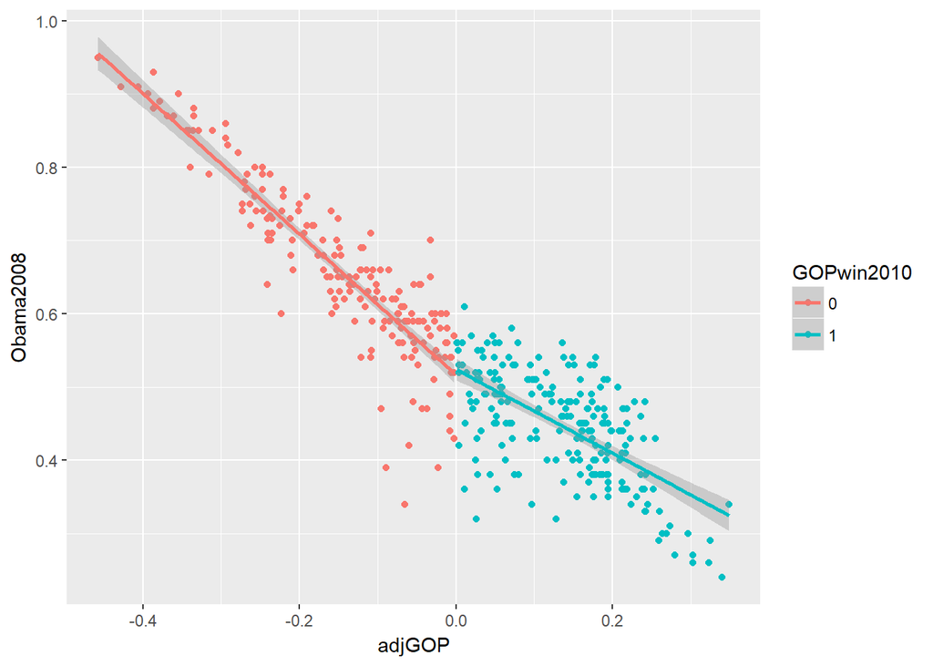

```r
# However removing the outliers removes the discontinuity
ggplot(data = filter(congress, abs(adjGOP) != 0.50)) +
  geom_point(aes(x = adjGOP, y = Obama2008, color = GOPwin2010)) +
  geom_smooth(aes(x = adjGOP, y = Obama2008, color = GOPwin2010), method = "lm")
```

We should be troubled by the discontinuities that appear in Obama share and white percentage, as this suggests that they cannot be used in a discontinuity design. However, it is important to note that when we remove the uncontested districts, the discontinuity disappears. This suggests that uncontested districts may introduce some bias into our statistical design.

```r
conVAR <- lm(Ideology ~ GOPwin2010 * adjGOP
             + ChildPoverty + MedianIncome + Obama2008 + WhitePct, data = congress)

tidy(conVAR)
```

```
##                 term      estimate    std.error  statistic       p.value
## 1        (Intercept) -1.340566e-02 1.272320e-01 -0.1053639  9.161369e-01
## 2        GOPwin20101  9.627815e-01 2.286945e-02 42.0990312 1.570623e-153
## 3             adjGOP -4.762371e-02 1.416603e-01 -0.3361824  7.368996e-01
## 4       ChildPoverty  2.651014e-01 1.885303e-01  1.4061474  1.604128e-01
## 5       MedianIncome  2.120959e-06 1.008738e-06  2.1025871  3.609088e-02
## 6          Obama2008 -7.905298e-01 1.242559e-01 -6.3621102  5.164714e-10
## 7           WhitePct -6.085770e-02 4.978006e-02 -1.2225318  2.221857e-01
## 8 GOPwin20101:adjGOP -1.770715e-01 1.365759e-01 -1.2965064  1.955062e-01
```

### (k)

```r
conVARquad <- lm(Ideology ~ GOPwin2010 * I(adjGOP ^ 2) + GOPwin2010 * adjGOP + ChildPoverty + MedianIncome + Obama2008 + WhitePct, data = congress)

tidy(conVARquad)
```

```
##                       term      estimate    std.error   statistic
## 1              (Intercept) -3.166341e-03 1.275785e-01 -0.02481877
## 2              GOPwin20101  9.088784e-01 3.255069e-02 27.92193698
## 3              I(adjGOP^2)  1.022459e+00 6.002693e-01  1.70333346
## 4                   adjGOP  4.515318e-01 3.048272e-01  1.48127126
## 5             ChildPoverty  2.659147e-01 1.878215e-01  1.41578397
## 6             MedianIncome  2.112532e-06 1.007358e-06  2.09710234
## 7                Obama2008 -7.364179e-01 1.265387e-01 -5.81970611
## 8                 WhitePct -7.393342e-02 4.991831e-02 -1.48108824
## 9  GOPwin20101:I(adjGOP^2) -1.709260e+00 7.442130e-01 -2.29673422
## 10      GOPwin20101:adjGOP -3.097497e-01 3.537159e-01 -0.87570209
##         p.value
## 1  9.802112e-01
## 2  6.185328e-98
## 3  8.924193e-02
## 4  1.392806e-01
## 5  1.575764e-01
## 6  3.657905e-02
## 7  1.167569e-08
## 8  1.393293e-01
## 9  2.212294e-02
## 10 3.816902e-01
```

```r
filtcong <- congress %>%
  filter(adjGOP > -0.1) %>%
  filter(adjGOP < 0.1)

filtVAR <-
  lm(Ideology ~ GOPwin2010 * adjGOP + ChildPoverty
     + MedianIncome + Obama2008 + WhitePct, data = filtcong)

tidy(filtVAR)
```

```
##                 term      estimate    std.error  statistic      p.value
## 1        (Intercept)  1.014672e-01 2.410422e-01  0.4209518 6.744136e-01
## 2        GOPwin20101  8.641359e-01 4.713429e-02 18.3334885 1.358749e-39
## 3             adjGOP  8.688370e-01 6.231758e-01  1.3942085 1.653873e-01
## 4       ChildPoverty  2.694340e-01 3.555991e-01  0.7576905 4.498659e-01
## 5       MedianIncome  9.332218e-07 1.745713e-06  0.5345793 5.937596e-01
## 6          Obama2008 -7.899501e-01 2.064849e-01 -3.8257040 1.932137e-04
## 7           WhitePct -5.493087e-02 8.914930e-02 -0.6161671 5.387503e-01
## 8 GOPwin20101:adjGOP -6.744964e-01 8.637691e-01 -0.7808758 4.361485e-01
```

We do see a shift from negative to positive on the adjusted GOP coefficient, however, it is still not statistically significant, so we cannot draw any conclusions from the results. Notably standard errors have also increased, as there is less data to draw from in order to make the regression.

### (m)

Though it does not show statistically significant results, the final windowed model seems most credible. Districts will be more similar to one another in the smaller window, and as a result it is closest to the intention of RD designs. This assumptions of RD design best hold when the movement over the mean is close to random, and a tighter window introduces this randomness. Those who are not in close races will have different pressures placed on them than those who are, which suggests that there are other variables that would need to be controlled for in order to include them in an RD design.

# Question 11.4

```r
headstart <- import("data/LudwigMiller_head_start.dta") %>%
  filter(!is.na(Poverty)) %>%
  filter(!is.na(Mortality))
```

### (a)

$$Mortality = \beta_0 + \beta_1 * HeadStart + \beta_2 * Poverty + \epsilon$$

### (b)

RD can estimate a causal effect because there is a clear cutoff for the application of the program, and municipalities are unlikely to be able to manipulate their poverty rate for inclusion into the program and will be randomly distributed around the line.

### (c)

```r
headVAR <- lm(Mortality ~ HeadStart + Poverty, data = headstart)

tidy(headVAR)
```

```
##          term   estimate  std.error statistic      p.value
## 1 (Intercept)  3.1094673 0.24384851 12.751635 2.456672e-36
## 2   HeadStart -0.9130971 0.43365749 -2.105572 3.532175e-02
## 3     Poverty  0.3376749 0.07790943  4.334198 1.509438e-05
```

We find that the head start program has a significant effect on mortality rate at the alpha equals 0.05 level and can thus reject the null hypothesis.

### (d)

```r
headVAR2 <- lm(Mortality ~ HeadStart * Poverty, data = headstart)

tidy(headVAR2)
```

```
##                term   estimate  std.error  statistic      p.value
## 1       (Intercept)  3.1009019 0.24552619 12.6296176 1.081019e-35
## 2         HeadStart -1.0267779 0.57416342 -1.7883025 7.382485e-02
## 3           Poverty  0.3346506 0.07856105  4.2597522 2.107414e-05
## 4 HeadStart:Poverty  0.1863191 0.61663021  0.3021569 7.625527e-01
```

The head start program no longer has a statistically significant effect on mortality rates, and we cannot reject the null hypothesis.

### (e)

```r
headfilt <- headstart %>%
  filter(Poverty > -0.8) %>%
  filter(Poverty < 0.8)

headfiltVAR <- lm(Mortality ~ HeadStart + Poverty, data = headfilt)

tidy(headfiltVAR)
```

```
##          term  estimate std.error statistic      p.value
## 1 (Intercept)  3.785846 0.5605933  6.753284 4.198139e-11
## 2   HeadStart -2.103486 0.9960812 -2.111762 3.522409e-02
## 3     Poverty  1.840813 1.0944909  1.681890 9.324197e-02
```

### (f)

```r
headquad <- lm(Mortality ~ HeadStart * Poverty + HeadStart * I(Poverty ^ 2), data = headstart)

tidy(headquad)
```

```
##                     term    estimate  std.error  statistic      p.value
## 1            (Intercept)  3.31972730 0.38071063  8.7198177 4.463264e-18
## 2              HeadStart -1.85127701 0.83463729 -2.2180617 2.662289e-02
## 3                Poverty  0.56339635 0.31412815  1.7935239 7.298669e-02
## 4           I(Poverty^2)  0.04392462 0.05840314  0.7520935 4.520520e-01
## 5      HeadStart:Poverty  2.17291614 2.06138270  1.0541061 2.919165e-01
## 6 HeadStart:I(Poverty^2) -1.25453341 1.06356975 -1.1795497 2.382699e-01
```

### (g)

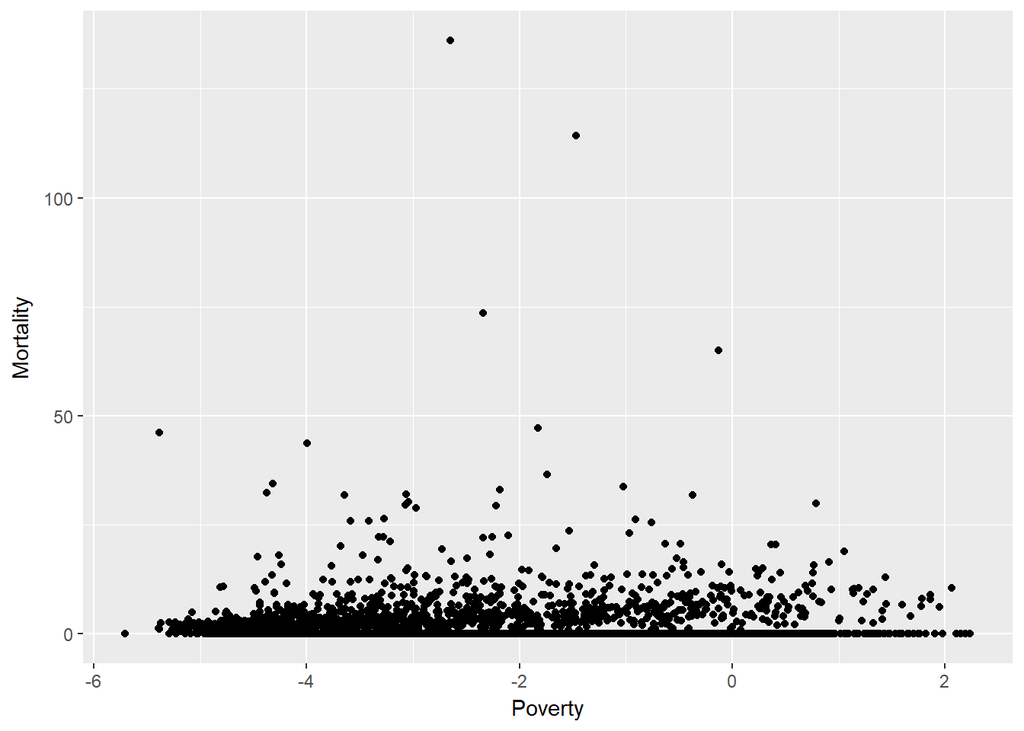

```r
ggplot(data = headstart) +
  geom_point(aes(x = Poverty, y = Mortality))
```

It is very difficult to see any discontinuity in this data as graphed.

### (h)

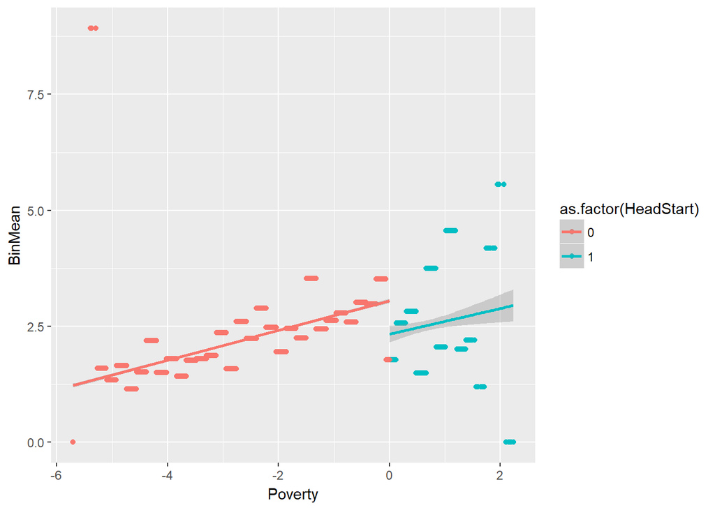

```r
ggplot(data = headstart) +
  geom_point(aes(x = Poverty, y = BinMean, color = as.factor(HeadStart))) +
  geom_smooth(aes(x = Poverty, y = BinMean, color = as.factor(HeadStart)), method = "lm")
```

There now appears to be a significant discontinuity in the data using the binned mean values.

### (i)

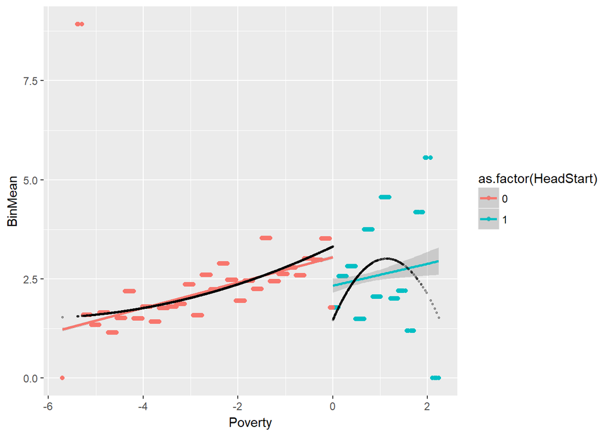

```r
headstart$fitted <- headquad$fitted.values

ggplot(data = headstart) +
  geom_point(aes(x = Poverty, y = BinMean, color = as.factor(HeadStart))) +
  geom_smooth(aes(x = Poverty, y = BinMean, color = as.factor(HeadStart)), method = "lm") +
  geom_point(aes(x = Poverty, y = fitted), size = 0.5, alpha = 0.33)
```

We’ve now included the fitted values from the quadratic model. While this model works well for the control group, for the treatment group the association seems more questionable. The binned means reveal that there is significant variance in the treatment group, which makes it difficult to determine the results of the head start program on mortality.

# Question 13.3

```r
bond <- import("data/BondUpdate.dta")
```

### (a)

```r
bondlm <- lm(GrossRev ~ Rating + Budget, data = bond)

tidy(bondlm)
```

```
##          term     estimate   std.error statistic    p.value
## 1 (Intercept) -590.8833844 365.9506205 -1.614653 0.12205252
## 2      Rating  172.6289093  52.7899822  3.270107 0.00383015
## 3      Budget    0.6222145   0.6009557  1.035375 0.31285138
```

We find a statistially significant correlation with the rating of the film and the Gross Revenue, a one unit increase in rating is associated on average with a increased gross revenue of 172 million pounds.

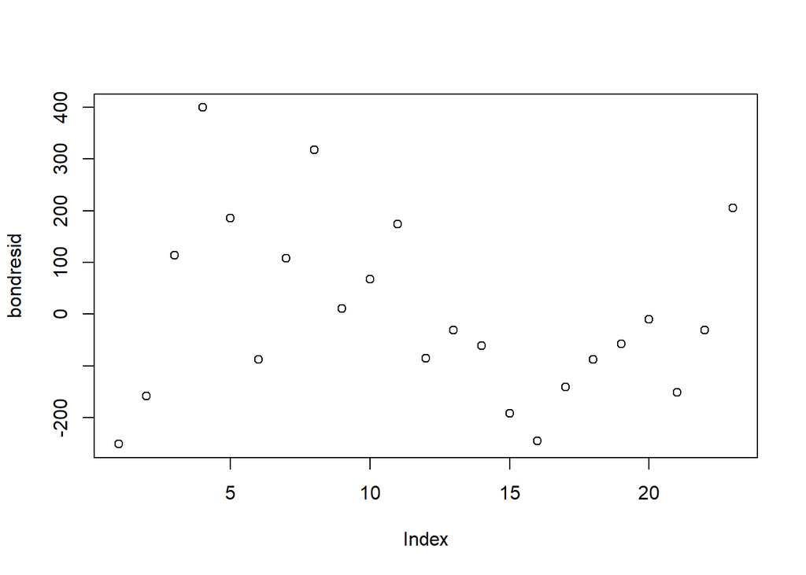

```r
bondresid <- resid(bondlm)

plot(bondresid)
```

```r
lagbond <- c(NA, bondresid[1:(length(bondresid) - 1)])

lagbondOLS <- lm(bondresid ~ lagbond)

summary(lagbondOLS)
```

```
##
## Call:
## lm(formula = bondresid ~ lagbond)
##
## Residuals:
##     Min      1Q  Median      3Q     Max
## -184.49 -123.64  -21.64  108.74  333.53
##
## Coefficients:
##             Estimate Std. Error t value Pr(>|t|)
## (Intercept)  15.4928    32.7731   0.473   0.6415
## lagbond       0.4398     0.1963   2.240   0.0366 *
## ---
## Signif. codes:  0 '***' 0.001 '**' 0.01 '*' 0.05 '.' 0.1 ' ' 1
##
## Residual standard error: 153.5 on 20 degrees of freedom
##   (1 observation deleted due to missingness)
## Multiple R-squared:  0.2005, Adjusted R-squared:  0.1606
## F-statistic: 5.017 on 1 and 20 DF,  p-value: 0.03662
```

We find a significant autocorrelation between the lagged bond gross revenue and the non-lagged term.

### (b)

```r
Rho = summary(lagbondOLS)$coefficients[2]

N = length(bond$GrossRev)

LagRev = c(NA, bond$GrossRev[1:(N - 1)])

LagOrder = c(NA, bond$order[1:(N - 1)])

RevRho <- mean(bond$GrossRev) - Rho * LagRev

OrderRho <- bond$order - Rho * LagOrder

RhoBond <- lm(RevRho ~ OrderRho + Rating + Budget, data = bond)

summary(RhoBond)
```

```
##
## Call:
## lm(formula = RevRho ~ OrderRho + Rating + Budget, data = bond)
##
## Residuals:
##     Min      1Q  Median      3Q     Max
## -123.03  -47.05   13.64   46.44  116.88
##
## Coefficients:
##             Estimate Std. Error t value Pr(>|t|)
## (Intercept) 200.2527   145.9373   1.372   0.1869
## OrderRho     27.6601     7.7955   3.548   0.0023 **
## Rating        9.4226    20.6423   0.456   0.6535
## Budget       -1.2260     0.4409  -2.781   0.0123 *
## ---
## Signif. codes:  0 '***' 0.001 '**' 0.01 '*' 0.05 '.' 0.1 ' ' 1
##
## Residual standard error: 68.61 on 18 degrees of freedom
##   (1 observation deleted due to missingness)
## Multiple R-squared:  0.4149, Adjusted R-squared:  0.3173
## F-statistic: 4.254 on 3 and 18 DF,  p-value: 0.01947
```

We no longer find a significant relationship between rating and gross revenue. Instead, we find a significant negative relatinoship between the budget and gross revenue at the alpha equals 0.05 level. A 1 million dollar increase on budget on average reduces revenue by 1.2 million dollars.

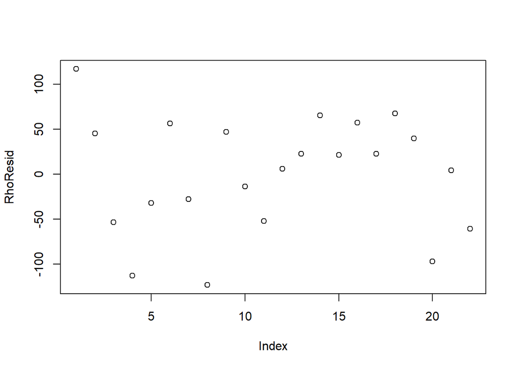

```r
RhoResid <- resid(RhoBond)

plot(RhoResid)
```

```r
lagrho <- c(NA, RhoResid[1:(length(RhoResid) - 1)])

lagrhoOLS <- lm(RhoResid ~ lagrho)

summary(lagrhoOLS)
```

```
##
## Call:
## lm(formula = RhoResid ~ lagrho)
##
## Residuals:
##     Min      1Q  Median      3Q     Max
## -112.91  -44.03   19.61   35.70   71.18
##
## Coefficients:
##             Estimate Std. Error t value Pr(>|t|)
## (Intercept)  -5.9965    13.1298  -0.457    0.653
## lagrho        0.1489     0.2113   0.704    0.490
##
## Residual standard error: 60.1 on 19 degrees of freedom
##   (1 observation deleted due to missingness)
## Multiple R-squared:  0.02545,    Adjusted R-squared:  -0.02584
## F-statistic: 0.4962 on 1 and 19 DF,  p-value: 0.4897
```

We no longer find autocorrelation in the model.

### (c)

```r
laggross<- c(NA, bond$GrossRev[1:(length(bond$GrossRev) - 1)])

dynamicbond <- lm(GrossRev ~ laggross + Rating + Budget, data = bond)

summary(dynamicbond)
```

```
##
## Call:
## lm(formula = GrossRev ~ laggross + Rating + Budget, data = bond)
##
## Residuals:
##     Min      1Q  Median      3Q     Max
## -208.27 -110.88   10.51   98.92  265.25
##
## Coefficients:
##               Estimate Std. Error t value Pr(>|t|)
## (Intercept) -1025.6207   299.0101  -3.430 0.002986 **
## laggross        0.5657     0.1598   3.540 0.002341 **
## Rating        190.7528    41.1841   4.632 0.000207 ***
## Budget          0.5178     0.4738   1.093 0.288861
## ---
## Signif. codes:  0 '***' 0.001 '**' 0.01 '*' 0.05 '.' 0.1 ' ' 1
##
## Residual standard error: 137.9 on 18 degrees of freedom
##   (1 observation deleted due to missingness)
## Multiple R-squared:  0.6539, Adjusted R-squared:  0.5962
## F-statistic: 11.34 on 3 and 18 DF,  p-value: 0.0002083
```

```r
LongTermBond <- dynamicbond$coefficients[3] / (1 - dynamicbond$coefficients[2])

LongTermBond
```

```
##   Rating
## 439.2288
```

The short term effect of a one unit increase in rating is an increase of 190 million dollars in gross revenue. The long term effect of a one unit increase in rating is expressed in the `LongTermBond` statistic, which is equal to 439 million dollars.

### (d)

```r
DeltaGross <- bond$GrossRev - laggross

LagDeltaGross <- c(NA, DeltaGross[1: (N - 1)])

DickeyGross <- lm(DeltaGross ~ laggross + order + LagDeltaGross, data = bond)

summary(DickeyGross)
```

```
##
## Call:
## lm(formula = DeltaGross ~ laggross + order + LagDeltaGross, data = bond)
##
## Residuals:
##     Min      1Q  Median      3Q     Max
## -307.16 -123.35  -36.54   96.66  482.93
##
## Coefficients:
##                Estimate Std. Error t value Pr(>|t|)
## (Intercept)   309.98724  284.65343   1.089    0.291
## laggross       -0.46867    0.33404  -1.403    0.179
## order          -0.35363    9.05463  -0.039    0.969
## LagDeltaGross   0.05768    0.29741   0.194    0.849
##
## Residual standard error: 210.7 on 17 degrees of freedom
##   (2 observations deleted due to missingness)
## Multiple R-squared:  0.1569, Adjusted R-squared:  0.008148
## F-statistic: 1.055 on 3 and 17 DF,  p-value: 0.3941
```

For Gross Revenue, the regression indicates that the data is non-stationary, which means we should move to a differenced model.

```r
lagbudget <- c(NA, bond$Budget[1: (N - 1)])

DeltaBudget <- bond$Budget - lagbudget

LagDeltaBudget <- c(NA, DeltaBudget[1: (N - 1)])

DickeyBudget <- lm(DeltaBudget ~ lagbudget + order + LagDeltaBudget, data = bond)

summary(DickeyBudget)
```

```
##
## Call:
## lm(formula = DeltaBudget ~ lagbudget + order + LagDeltaBudget,
##     data = bond)
##
## Residuals:
##     Min      1Q  Median      3Q     Max
## -60.308 -23.257  -6.795  25.045  84.244
##
## Coefficients:
##                Estimate Std. Error t value Pr(>|t|)
## (Intercept)    -8.25273   19.09084  -0.432   0.6710
## lagbudget      -0.63175    0.32748  -1.929   0.0706 .
## order           5.62689    2.70645   2.079   0.0531 .
## LagDeltaBudget -0.07566    0.29595  -0.256   0.8013
## ---
## Signif. codes:  0 '***' 0.001 '**' 0.01 '*' 0.05 '.' 0.1 ' ' 1
##
## Residual standard error: 35.82 on 17 degrees of freedom
##   (2 observations deleted due to missingness)
## Multiple R-squared:  0.3463, Adjusted R-squared:  0.2309
## F-statistic: 3.001 on 3 and 17 DF,  p-value: 0.0595
```

```r
lagRating <- c(NA, bond$Rating[1: (N - 1)])

DeltaRating <- bond$Rating - lagRating

LagDeltaRating <- c(NA, DeltaRating[1: (N - 1)])

DickeyRating <- lm(DeltaRating ~ lagRating + order + LagDeltaRating, data = bond)

summary(DickeyRating)
```

```
##
## Call:
## lm(formula = DeltaRating ~ lagRating + order + LagDeltaRating,
##     data = bond)
##
## Residuals:
##     Min      1Q  Median      3Q     Max
## -1.0440 -0.3841 -0.1609  0.3409  1.4265
##
## Coefficients:
##                Estimate Std. Error t value Pr(>|t|)
## (Intercept)     2.36852    2.16975   1.092   0.2902
## lagRating      -0.41114    0.29962  -1.372   0.1878
## order           0.02457    0.02757   0.891   0.3853
## LagDeltaRating -0.47270    0.23978  -1.971   0.0652 .
## ---
## Signif. codes:  0 '***' 0.001 '**' 0.01 '*' 0.05 '.' 0.1 ' ' 1
##
## Residual standard error: 0.6772 on 17 degrees of freedom
##   (2 observations deleted due to missingness)
## Multiple R-squared:  0.4976, Adjusted R-squared:  0.409
## F-statistic: 5.613 on 3 and 17 DF,  p-value: 0.007319
```

Finally, with rating, we once again find no significance on the Dickey-Fuller test, meaning the data is non-stationary and we should implement a differenced model.

### (e)

```r
DiffModel <- lm(DeltaGross ~ LagDeltaGross + DeltaBudget + DeltaRating)

summary(DiffModel)
```

```
##
## Call:
## lm(formula = DeltaGross ~ LagDeltaGross + DeltaBudget + DeltaRating)
##
## Residuals:
##      Min       1Q   Median       3Q      Max
## -312.263  -97.617   -5.694  104.583  265.073
##
## Coefficients:
##               Estimate Std. Error t value Pr(>|t|)
## (Intercept)     1.9796    42.7566   0.046    0.964
## LagDeltaGross   0.1232     0.2552   0.483    0.635
## DeltaBudget     2.1827     1.4201   1.537    0.143
## DeltaRating   201.1315    70.5423   2.851    0.011 *
## ---
## Signif. codes:  0 '***' 0.001 '**' 0.01 '*' 0.05 '.' 0.1 ' ' 1
##
## Residual standard error: 186.1 on 17 degrees of freedom
##   (2 observations deleted due to missingness)
## Multiple R-squared:  0.3428, Adjusted R-squared:  0.2268
## F-statistic: 2.955 on 3 and 17 DF,  p-value: 0.06203
```

With the differenced model we find that the rating of the film correlates strongly with the revenue. A one unit increase in the rating of the film increases the revenue by 201 million dollars.

### (f)

```r
DiffModelActor <- lm(DeltaGross ~ LagDeltaGross +
                       DeltaBudget + DeltaRating + Actor, data = bond)

summary(DiffModelActor)
```

```
##
## Call:
## lm(formula = DeltaGross ~ LagDeltaGross + DeltaBudget + DeltaRating +
##     Actor, data = bond)
##
## Residuals:
##     Min      1Q  Median      3Q     Max
## -332.18  -64.51   12.91   80.69  259.77
##
## Coefficients:
##                Estimate Std. Error t value Pr(>|t|)
## (Intercept)     28.4163   103.3474   0.275   0.7880
## LagDeltaGross   -0.0983     0.2963  -0.332   0.7458
## DeltaBudget      1.8975     1.6698   1.136   0.2780
## DeltaRating    179.9989    91.2623   1.972   0.0721 .
## ActorConnery   103.7267   141.3999   0.734   0.4773
## ActorCraig      34.8142   151.8894   0.229   0.8226
## ActorDalton   -134.3512   165.0488  -0.814   0.4315
## ActorLazenby  -309.1929   236.1223  -1.309   0.2149
## ActorMoore     -56.8715   128.1158  -0.444   0.6650
## ---
## Signif. codes:  0 '***' 0.001 '**' 0.01 '*' 0.05 '.' 0.1 ' ' 1
##
## Residual standard error: 188.6 on 12 degrees of freedom
##   (2 observations deleted due to missingness)
## Multiple R-squared:  0.5233, Adjusted R-squared:  0.2054
## F-statistic: 1.646 on 8 and 12 DF,  p-value: 0.2103
```

We do not find that a change in actor has a significant effect on the revenue of a Bond film, and thus we cannot reject the null hypothesis that the actor for Bond has no effect on the revenue of the film.

# Question 15.1

```r
olympic <- import("data/olympics_HW.dta")
```

### (a)

```r
onewayolympic <- lm(medals ~ population + GDP + host + temp + elevation + country, data = olympic)

tidy(onewayolympic)
```

```
##                               term      estimate    std.error
## 1                      (Intercept) -5.274986e-01 12.321497908
## 2                       population  1.282955e-02  0.003562288
## 3                              GDP  8.165972e-01  0.097428385
## 4                             host  5.764501e+00  0.995971671
## 5                             temp -3.118156e-05  0.051439845
## 6                        elevation  1.294068e-04  0.004664436
## 7                  countryAlgeria  -4.404192e-01  2.009469925
## 8                  countryAndorra  -1.481616e+00  2.099728359
## 9                countryArgentina  -1.270073e+00 20.221976995
## 10                 countryArmenia  -1.519827e-01  7.178787392
## 11               countryAustralia  -7.504564e-01  2.187480888
## 12                 countryAustria   1.158649e+01  5.796515908
## 13              countryAzerbaijan  -3.119286e-01  8.844035954
## 14                 countryBelarus   2.271073e+00 10.671779553
```

[output cut: 209 more lines]

We estimate that population, GDP, and host country all play a significant positive role in the medal count during the Olympics at the alpha equals 0.05 level. Temperature and elevation do not play a significant role, and the coefficients imply that they do not have a substantive effect either.

### (b)

```r
olympictwoway <- plm(medals ~ population + GDP + host,
                data = olympic,
                index = c("country", "year"),
                model = "within",
                effect = "twoways")

tidy(olympictwoway)
```

```
##         term    estimate   std.error statistic      p.value
## 1 population 0.008549258 0.003754531  2.277051 2.303446e-02
## 2        GDP 0.593507203 0.123049435  4.823323 1.676849e-06
## 3       host 5.712385319 0.988933701  5.776308 1.075839e-08
```

We find that these three variables (population, GDP, and host country) are still significant at the alpha equals 0.05 level. Population and GDP, however, are somewhat less significant now, and the coefficients show a smaller substantive effect. Populations and GDPs will grow over time, so we would expect that including time would remove some of the effects of these variables.

### (c)

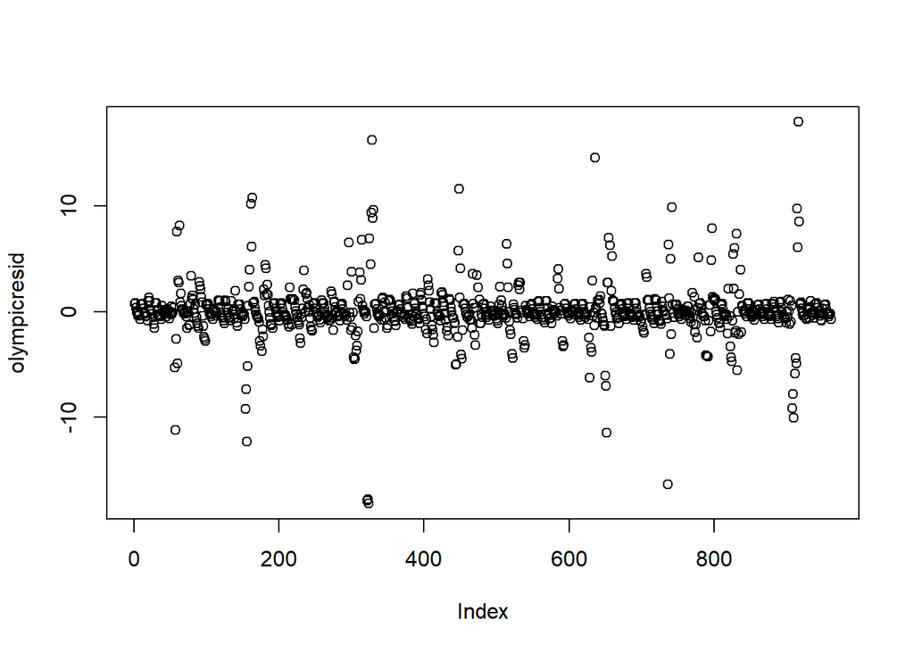

```r
olympicresid <- resid(olympictwoway)

plot(olympicresid)
```

```r
lagolympic <- c(NA, olympicresid[1:(length(olympicresid) - 1)])

lagolympicOLS <- lm(olympicresid ~ lagolympic)

summary(lagolympicOLS)
```

```
##
## Call:
## lm(formula = olympicresid ~ lagolympic)
##
## Residuals:
##      Min       1Q   Median       3Q      Max
## -17.6820  -0.4840  -0.1695   0.4370  15.2085
##
## Coefficients:
##              Estimate Std. Error t value Pr(>|t|)
## (Intercept) -0.001091   0.073856  -0.015    0.988
## lagolympic   0.446442   0.028910  15.442   <2e-16 ***
## ---
## Signif. codes:  0 '***' 0.001 '**' 0.01 '*' 0.05 '.' 0.1 ' ' 1
##
## Residual standard error: 2.288 on 958 degrees of freedom
##   (1 observation deleted due to missingness)
## Multiple R-squared:  0.1993, Adjusted R-squared:  0.1985
## F-statistic: 238.5 on 1 and 958 DF,  p-value: < 2.2e-16
```

We find highly significant autocorrelation in the dependent variable. This implies we should correct for autocorrelation by including Rho variables.

### (d)

```r
Rho = summary(lagolympicOLS)$coefficients[2]

N = length(olympic$medals)

LagMedals = c(NA, olympic$medals[1:(N - 1)])

LagYear = c(NA, olympic$year[1:(N - 1)])

MedalsRho <- mean(olympic$medals) - Rho * LagMedals

YearRho <- olympic$year - Rho * LagYear

olympic$YearRho <- YearRho

RhoOlympic <- plm(MedalsRho ~ population + GDP + host,
                data = olympic,
                index = c("country", "YearRho"),
                model = "within",
                effect = "twoways")
```

```
## at least one couple (id-time) has NA in at least one index dimension in resulting pdata.frame
##  to find out which, use e.g. table(index(your_pdataframe), useNA = "ifany")
```

```r
summary(RhoOlympic)
```

```
## Twoways effects Within Model
##
## Call:
## plm(formula = MedalsRho ~ population + GDP + host, data = olympic,
##     effect = "twoways", model = "within", index = c("country",
##         "YearRho"))
##
## Unbalanced Panel: n=111, T=1-10, N=960
##
## Residuals :
##    Min. 1st Qu.  Median 3rd Qu.    Max.
## -10.200  -0.379   0.093   0.302   7.710
##
## Coefficients :
##               Estimate  Std. Error t-value Pr(>|t|)
## population  0.00039391  0.00212523  0.1853 0.853000
## GDP        -0.22693808  0.06986494 -3.2482 0.001208 **
## host       -0.68400970  0.56849692 -1.2032 0.229244
## ---
## Signif. codes:  0 '***' 0.001 '**' 0.01 '*' 0.05 '.' 0.1 ' ' 1
##
## Total Sum of Squares:    2028
## Residual Sum of Squares: 1997.9
## R-Squared:      0.014847
## Adj. R-Squared: -0.13145
## F-statistic: 4.19482 on 3 and 835 DF, p-value: 0.005858
```

We now find that both GDP plays a highly significant role in medal count. However, the role it plays is negative in this model. For every unit increase in GDP, the country on average receives 0.227 less medals. The first model is preferable, as this model does not pass face validity, it is highly unlikely that GDP would have such a negative effect on medal count. This does not mesh well with any theory for medal count, countries with higher GDP can invest much more into athletic infrastructure.

### (e)

```r
LagReg <- plm(medals ~ LagMedals + population + GDP + host,
                data = olympic,
                index = c("country", "year"),
                model = "within",
                effect = "twoways")

summary(LagReg)
```

```
## Twoways effects Within Model
##
## Call:
## plm(formula = medals ~ LagMedals + population + GDP + host, data = olympic,
##     effect = "twoways", model = "within", index = c("country",
##         "year"))
##
## Unbalanced Panel: n=111, T=1-10, N=961
##
## Residuals :
##     Min.  1st Qu.   Median  3rd Qu.     Max.
## -13.1000  -0.4650  -0.0986   0.5080  18.4000
##
## Coefficients :
##             Estimate Std. Error t-value  Pr(>|t|)
## LagMedals  0.3146559  0.0241948 13.0051 < 2.2e-16 ***
## population 0.0085312  0.0034265  2.4898 0.0129751 *
## GDP        0.4189832  0.1130975  3.7046 0.0002256 ***
## host       5.2515080  0.9032252  5.8142 8.664e-09 ***
## ---
## Signif. codes:  0 '***' 0.001 '**' 0.01 '*' 0.05 '.' 0.1 ' ' 1
##
## Total Sum of Squares:    6701.3
## Residual Sum of Squares: 5212.5
## R-Squared:      0.22216
## Adj. R-Squared: 0.10786
## F-statistic: 59.7654 on 4 and 837 DF, p-value: < 2.22e-16
```

We find a highly similar result to the two-way fixed effect model in part (b), except now the lagged value for medals also plays a significant role in the result, drawing some small amount of explanatory value from the other three variables. This means that countries which won medals in the last olympics are likely to win medals in the next. We might see this as a result of athletes in these countries which participate in multiple olympic games in a row.

### (f)

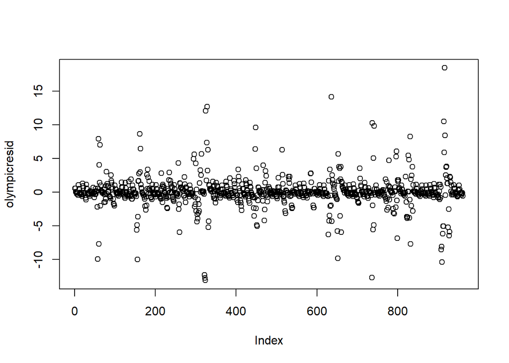

```r
olympicresid <- resid(LagReg)

plot(olympicresid)
```

```r
lagolympic <- c(NA, olympicresid[1:(length(olympicresid) - 1)])

lagolympicOLS <- lm(olympicresid ~ lagolympic)

summary(lagolympicOLS)
```

```
##
## Call:
## lm(formula = olympicresid ~ lagolympic)
##
## Residuals:
##      Min       1Q   Median       3Q      Max
## -12.5889  -0.4237  -0.1325   0.3863  17.2975
##
## Coefficients:
##              Estimate Std. Error t value Pr(>|t|)
## (Intercept) -0.000696   0.073877  -0.009    0.992
## lagolympic   0.192304   0.031705   6.065 1.89e-09 ***
## ---
## Signif. codes:  0 '***' 0.001 '**' 0.01 '*' 0.05 '.' 0.1 ' ' 1
##
## Residual standard error: 2.289 on 958 degrees of freedom
##   (1 observation deleted due to missingness)
## Multiple R-squared:  0.03698,    Adjusted R-squared:  0.03598
## F-statistic: 36.79 on 1 and 958 DF,  p-value: 1.893e-09
```

We find highly significant autocorrelation in this result, which suggest we may have a biased result. This implies we should rho-transformed regression to control for autocorrelation.

### (g)

```r
LagRegRho <- plm(MedalsRho ~ LagMedals + population + GDP + host,
                data = olympic,
                index = c("country", "YearRho"),
                model = "within",
                effect = "twoways")
```

```
## at least one couple (id-time) has NA in at least one index dimension in resulting pdata.frame
##  to find out which, use e.g. table(index(your_pdataframe), useNA = "ifany")
```

```r
summary(LagRegRho)
```

```
## Twoways effects Within Model
##
## Call:
## plm(formula = MedalsRho ~ LagMedals + population + GDP + host,
##     data = olympic, effect = "twoways", model = "within", index = c("country",
##         "YearRho"))
##
## Unbalanced Panel: n=111, T=1-10, N=960
##
## Residuals :
##      Min.   1st Qu.    Median   3rd Qu.      Max.
## -1.05e-14 -5.18e-16 -1.63e-16  1.59e-16  9.00e-14
##
## Coefficients :
##               Estimate  Std. Error     t-value Pr(>|t|)
## LagMedals  -4.4644e-01  3.2957e-17 -1.3546e+16   <2e-16 ***
## population  2.1716e-18  4.5336e-18  4.7900e-01   0.6321
## GDP         9.9668e-17  1.4997e-16  6.6460e-01   0.5065
## host       -7.6683e-17  1.2138e-15 -6.3200e-02   0.9496
## ---
## Signif. codes:  0 '***' 0.001 '**' 0.01 '*' 0.05 '.' 0.1 ' ' 1
##
## Total Sum of Squares:    2028
## Residual Sum of Squares: 9.0805e-27
## R-Squared:      1
## Adj. R-Squared: 1
## F-statistic: 4.65651e+31 on 4 and 834 DF, p-value: < 2.22e-16
```

We no longer find statistically significant effects from population, GDP, or host country. Instead, the only significant coefficient is on `LagMedals`, but it is highly negative. This would imply that medals previously won have a negative effect on the probability of winning future medals. This seems highly unlikely and calls the model into question.

### (h)

Bias is not a serious problem when there are 20 or more time periods, as noted in 15.2. However, in this data set we have data from 1984 to 2014, or 10 periods, which is not enough to reduce this bias. Thus any results using lagged data are suspect.

### (i)

The fact that athletes compete in multiple olympics and that this suggests that truly skilled athletes would continue winning medals for their countries at a high rate (see Micheal Phelps, Usain Bolt) would imply that this model is somewhat dynamic. As section 13.4 suggests, if we have good reason to suspect that a dependent variable is dymamic we should include the lagged term. This may introduce some bias in the case of autocorrelation, however, we know that if we do not include the term we risk omitted variable bias. As such it is best to use a model as close to the theoretical process as possible, which is the dynamic model.

### (j)

These models are not robust as the explanatory variables are not resistant to change when we move from model to model. In some models the variables appear significant while in others they do not. Moreover the substantive effect changes as well from model to model. We find that sometimes variables appear to have a positive substantive effect, while at other times they have one which is negative.